# 104.5. Image subsets with the Butler

For the Rubin Science Platform at data.lsst.cloud.  
Data Release: [Data Preview 2](https://dp2.lsst.io/)  
Container Size: Large  
LSST Science Pipelines version: r30.0.11  
Last verified to run: 2026-09-24  
Repository: github.com/lsst/tutorial-notebooks  
DOI: 10.11578/rubin/dc.20250909.20

**Learning objective:** How to make image subsets with the Butler.

**LSST data products:** `deep_coadd`

**Packages:** `lsst.daf.butler`, `lsst.images`, `lsst.afw`

**Credit:** Originally developed by the Rubin Community Science team. Please consider acknowledging them if this notebook is used for the preparation of journal articles, software releases, or other notebooks.

**Get Support:** Everyone is encouraged to ask questions or raise issues in the [Support Category](https://community.lsst.org/c/support) of the Rubin Community Forum. Rubin staff will respond to all questions posted there.

## 1. Introduction

This notebook demonstrates how to make image subsets (a smaller piece of a parent LSST image) using the Butler. This method for generating small image subsets is the right tool when small images are desired from a single visit image or deep coadd patch, or, when the analysis workflow is already using the Butler for image analysis. Instead, the Rubin cutout service is a better tool when wanting to generate image cutouts at a range of coordinates or observations times. The Rubin cutout service is demonstrated in notebooks in the DP1 or DP2 103 notebook series.

Butler-related documentation:

- [pipelines middleware Frequently Asked Questions](https://pipelines.lsst.io/middleware/index.html)
- [Butler python module documentation](https://pipelines.lsst.io/modules/lsst.daf.butler/index.html)
- [Butler query expressions and operators](https://pipelines.lsst.io/modules/lsst.daf.butler/queries.html#datasettype-expressions)

**This tutorial** demonstrates how to generate image subsets using the Butler using a variety of methods.

**Related tutorials:** The earlier 100-level Butler tutorials in this series show how to retrieve data with the Butler and how to explore and discover the dataset types and their properties. The 103 series demonstrate the Rubin cutout service to produce image cutouts.

### 1.1. Import packages

Import the `butler` module from the `lsst.daf` package, and the `display` module from the `lsst.afw` package (for image display). Import the `lsst.sphgeom` packages to enable spatial and subset functionality. The `lsst.images` package imports handling for LSST image types for releases DP2 and later.

```python
import matplotlib.pyplot as plt
import math
from lsst.daf.butler import Butler
import lsst.sphgeom as sphgeom
import lsst.afw.display as afw_display
from lsst.images import Box, Interval
from astropy.coordinates import SkyCoord
from astropy.visualization import ZScaleInterval
```

### 1.2. Define parameters

Create an instance of the Butler with the repository and collection for DP2.

```python
butler = Butler('dp2', collections="dp2")
```

Set `afwDisplay` to use matplotlib.

```python
afw_display.setDefaultBackend('matplotlib')
```

**Coordinates:** Use coordinates RA, Dec = $53.076, -28.110$ deg, which are near the center of the Extended Chandra Deep Field South (ECDFS).

**Region:** Define a circle with a radius of 0.1 deg, centered on the coordinates.

```python
ra = 53.076
dec = -28.110
band = 'r'

radius = 0.1
region = sphgeom.Region.from_ivoa_pos(f"CIRCLE {ra} {dec} {radius}")
```

## 2. The Bounding Box

Note that the bounding box is indexed as (y, x) with the y direction first.

### 2.1. Identify deep_coadds

First, query the Butler for r-band images that overlap the sky region defined above.

```python
dataset_refs = butler.query_datasets("deep_coadd",
                                     where="band.name='r' AND\
                                     patch.region OVERLAPS POINT(ra, dec)",
                                     bind={"ra": ra, "dec": dec},
                                     with_dimension_records=True,
                                     order_by=["patch.tract"])
```

Get the `dataId` for the first returned dataset reference.

```python
coadd = butler.get(dataset_refs[0])
dataId = dataset_refs[0].dataId
print(dataId)
```

```
{band: 'r', skymap: 'lsst_cells_v2', tract: 5063, patch: 15}
```

### 2.2. Access image boundaries

To retrieve the bounding box that defines the full `deep_coadd`, use the `bbox` method. By default, `bbox` returns pixel coordinates in the absolute coordinate system of the entire image tract. The first and last pixels in the x and y direction of the image can be accessed using the `.start` and `.stop` methods.

```python
bbox = coadd.bbox
print('bbox defined using .bbox of existing image', bbox)

print(f"X-pixel range: [{bbox.x.start}, {bbox.x.stop}]")
print(f"Y-pixel range: [{bbox.y.start}, {bbox.y.stop}]")
```

```
bbox defined using .bbox of existing image [y=2850:6150, x=14850:18150]
X-pixel range: [14850, 18150]
Y-pixel range: [2850, 6150]
```

```python
print(f"X-pixel range: [{bbox.x.min}, {bbox.x.max}]")
print(f"Y-pixel range: [{bbox.y.min}, {bbox.y.max}]")
```

```
X-pixel range: [14850, 18149]
Y-pixel range: [2850, 6149]
```

### 2.3. Define subset boundaries

Below, construct a new bounding box using the Box function to define a subset region of the full `deep_coadd`.

The `Box` function is part of the `lsst.images` package, and can also take explicit x and y keyword arguments, so that there is no confusion about the axes. In this case, an interval of x and y coordinates must be constructed using the `Interval` function in order for `bbox` to be in the correct format.

```python
x_interval = Interval(bbox.x.start+100, bbox.x.stop-100)
y_interval = Interval(bbox.y.start+100, bbox.y.stop-100)

print("correct pixel range format: ", x_interval)

bbox = Box(x=x_interval, y=y_interval)
print(bbox)
```

```
correct pixel range format:  14950:18050
[y=2950:6050, x=14950:18050]
```

Equivalently, this can be achieved using the `.padded` method that shrinks the bounds of the existing bounding box by 100 pixels, but achieves the same format without needing the `Interval` or `Box` functions.

```python
smaller_box = coadd.bbox.padded(-100)
x_interval = smaller_box.x
y_interval = smaller_box.y
print(smaller_box)
print(x_interval, y_interval)
```

```
[y=2950:6050, x=14950:18050]
14950:18050 2950:6050
```

### 2.4 Local vs absolute coordinates

By default, all pixel coordinates are in the absolute coordinate system (i.e. that of the parent tract to which the `deep_coadd` belongs).

If one wants to specify using the local array pixel coordinates (rather than absolute coordinates) then this can be done using the `local` method and pass the range of x and y pixels in local coordinates directly. Note however that the bounding box itself will still be in the absolute (parent patch/tract) coordinate system, even if defined initially in local coordinates (which is demonstrated below using the `start` and `stop` methods). Find documentation on the `CellCoadd.local` property at images.lsst.io.

```python
coadd_local = coadd.local[10:1000, 10:1000]
print(coadd_local.bbox)
print(f"X-pixel range: [{coadd_local.bbox.x.start}, {coadd_local.bbox.x.stop}]")
print(f"Y-pixel range: [{coadd_local.bbox.y.start}, {coadd_local.bbox.y.stop}]")
```

```
[y=2860:3850, x=14860:15850]
X-pixel range: [14860, 15850]
Y-pixel range: [2860, 3850]
```

### 2.5. Sky coordinates

The bounding box can also be defined starting with sky coordinates (converted to pixels) in the following way. Retrieving the world coordinate system (WCS) of the `deep_coadd` with the `sky_projection` method enables converting an ra, dec to pixel coordinates of the desired image.

```python
point = SkyCoord(ra, dec, unit='deg')
xy = coadd.sky_projection.sky_to_pixel(point)
print(point, xy)
```

```
<SkyCoord (ICRS): (ra, dec) in deg
    (53.076, -28.11)> XY(x=15182.507513158846, y=4390.517978014746)
```

Then, define a spatial extent for the image subset (e.g. 60 arcseconds) and convert those to pixel coordinates to define the bounding box. `Box.factory` is a special property that can indexed to create a new box, is more concise, and harder to get wrong than passing x and y arguments to `Box()` as was done in Section 2.3.

```python
pixel_scale_arcsec = 0.2
subset_side_arcsec = 60.0
subset_side_pixels = int(subset_side_arcsec / pixel_scale_arcsec)
half_edge = subset_side_pixels // 2
print(half_edge)
print(xy.y)

bbox_sky = Box.factory[round(xy.y):round(xy.y)+1, round(xy.x):round(xy.x)+1].padded(half_edge)
print(bbox_sky)
```

```
150
4390.517978014746
[y=4241:4542, x=15033:15334]
```

Alternatively, if the pixel range is already known it can be entered into `Box.factory` directly as below.

```python
bbox = Box.factory[4241:4542, 15033:15334]
```

## 3. Generate image subsets

The last section explored how to access and construct bounding boxes. This section demonstrates how to use the bounding boxes to generate the image subsets.

### 3.1 Pass bounding box to the butler

Below, pass the bounding box to the butler in the parameters dictionary directly. This saves memory and time by only loading the requested pixels, rather than retrieving the full image first and generating the subset after loading it into memory.

Below, pass the bounding box to the Butler with the `parameters` keyword to request a subset of the `deep_coadd` image defined using the `bbox`. The output is an image with dimensions that match the bounding box in `CellCoadd` format (the new equivalent of `ExposureF` in the `lsst.images` image format).

```python
subset = butler.get('deep_coadd', dataId=dataId, parameters={'bbox': bbox})
print(subset)
```

```
CellCoadd([y=4241:4542, x=15033:15334], tract=5063)
```

Display the image subset returned by the butler.

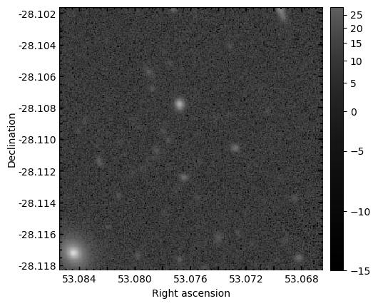

```python
display = afw_display.Display(frame=1)
display.scale('asinh', 'zscale')
display.image(subset.image)
plt.show()
```

> **Figure 1:** A subset of a sky region in the ECDFS returned after passing a bounding box to the Butler

### 3.2. Subsets from a full exposure

It is also possible to make subsets after retrieving the full `deep_coadd` from the butler. This may be preferable if many subsets are needed from the same patch and tract image.

First, retrieve the full `deep_coadd` of interest.

```python
full_exposure = butler.get('deep_coadd', dataId=dataId)
```

Extract the region of interest using direct bounding box indexing on the full `deep_coadd` exposure. A simple example would look like:

`subset_exposure = full_exposure[bbox_sky]`

Note that `subset` is not creating a "deep copy" (equivalent of `deep_copy` from python's built-in `copy` module) of the image by default. The subset points to the same block of memory as the parent `full_exposure`. No new pixel data is duplicated into memory. While this is efficient in that it is quick and uses less memory, because the subset and the parent share the same memory, modifying one modifies the other. Any change to the pixel values in the subset will apply also to the `full_exposure` stored in memory. Any operations that are performed on the pixel array generated by the `subset` method, `subset_subset`, will also happen to `full_exposure`. Note that this means that even if the full image is deleted to save memory, the whole original memory block will continue to remain allocated until the image subset is also deleted.

Alternatively, use the `.copy()` method to make a copy of the subset from the full coadd that does not overwrite the memory location of the original:

`subset_copy = full_exposure[bbox_sky].copy()`

Using the `copy` method is instead is like `deep_copy` in that it allocates new memory and physically duplicates the subset into a new image object. This allows the user to apply mathematical operations on the subset without altering the the `full_exposure` image also stored in memory. However, it takes longer to execute and uses more memory (though for small or few subsets this is negligible).

The use case for `copy`: When the user already has the full image from the butler in memory, and wants to make one or more subsets from it. Generate such a subset to independent memory below, and leave `full_exposure` stored in memory in its original form.

```python
subset_exposure = full_exposure[bbox_sky].copy()
```

Plot the image extension of the subset.

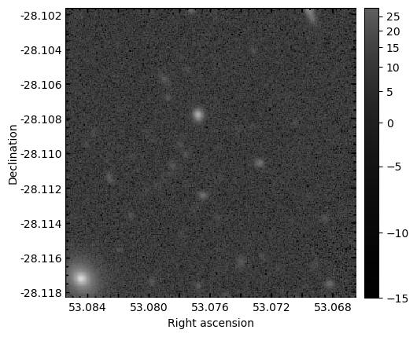

```python
display = afw_display.Display(frame=1)
display.scale('asinh', 'zscale')
display.image(subset_exposure.image)
plt.show()
```

> **Figure 2:** A subset of the ECDFS but generated using the bounding box indexing method

### 3.3. Convenience methods

Some properties of the subset can be accessed with methods such as `.shape`, and image extensions using `.image` or `.variance`

Values of interest to defining the subset, including including the dimensions of the bounding box can be accessed through the `shape` method.

```python
print(f"Successfully created subset of shape: {subset.image.array.shape}")
```

```
Successfully created subset of shape: (301, 301)
```

```python
print("The pixel dimensions of the coadd are ", bbox.shape.x, bbox.shape.y)
```

```
The pixel dimensions of the coadd are  301 301
```

It can be useful to first check whether an image subset defined by a bounding box is inside the full deep_coadd image before attempting to generate the subset, to avoid errors. Do this using the `contains` method.

```python
print(full_exposure.bbox.contains(bbox_sky))
```

```
True
```

The `intersection` method generates a new bounding box for an overlapping region between two bounding boxes. In the case below, `bbox_sky` is fully contained within the bounding box of `full_exposure` and so `bbox_sky` is returned.

```python
print(bbox_sky)
print(full_exposure.bbox)
bbox_overlap = full_exposure.bbox.intersection(bbox_sky)
print(bbox_overlap)
```

```
[y=4241:4542, x=15033:15334]
[y=2850:6150, x=14850:18150]
[y=4241:4542, x=15033:15334]
```

## 4. Retrieve multiple subsets from the butler

First, define a list of targets in a dictionary containing bright (V band magnitude < 22) variability selected galaxies hosting active galactic nuclei (AGN) in the ECDFS field from [Boutsia et al. 2009](https://ui.adsabs.harvard.edu/abs/2009A%26A...497...81B/abstract). Use the `sky_projection.sky_to_pixel` methods to convert the ra and dec to pixel coordinates.

```python
targets = [{'id': '3', 'ra': 53.335875, 'dec': -27.819472},
           {'id': '8', 'ra': 53.194833, 'dec': -28.146306},
           {'id': '9', 'ra': 53.411917, 'dec': -27.671222},
           {'id': '11', 'ra': 53.318792, 'dec': -27.844306},
           {'id': '12', 'ra': 53.191458, 'dec': -27.962583},
           {'id': '14', 'ra': 53.133333, 'dec': -28.052750},
           {'id': '15', 'ra': 52.977708, 'dec': -28.176583},
           {'id': '18', 'ra': 53.380708, 'dec': -27.942833},
           {'id': '20', 'ra': 53.049333, 'dec': -28.153056},
           {'id': '22', 'ra': 53.370542, 'dec': -27.944750},
           {'id': '24', 'ra': 53.290458, 'dec': -27.937222},
           {'id': '25', 'ra': 52.819542, 'dec': -27.724889},
           {'id': '26', 'ra': 53.144042, 'dec': -28.053889},
           {'id': '28', 'ra': 53.337875, 'dec': -27.653278},
           {'id': '29', 'ra': 53.155375, 'dec': -28.146389},
           {'id': '30', 'ra': 53.302625, 'dec': -27.931000},
           {'id': '31', 'ra': 52.797417, 'dec': -27.692194},
           {'id': '32', 'ra': 53.344958, 'dec': -27.923278},
           {'id': '33', 'ra': 53.224583, 'dec': -27.898361},
           {'id': '34', 'ra': 53.359333, 'dec': -27.974917},
           {'id': '35', 'ra': 53.084583, 'dec': -28.037444},
           {'id': '36', 'ra': 53.132417, 'dec': -28.119556},
           {'id': '37', 'ra': 53.371750, 'dec': -27.990750},
           {'id': '39', 'ra': 53.184083, 'dec': -28.174583},
           {'id': '41', 'ra': 52.992208, 'dec': -28.044861},
           {'id': '43', 'ra': 53.333375, 'dec': -27.986778},
           {'id': '44', 'ra': 52.812667, 'dec': -27.921833}]
```

First set up some useful parameters to generate nice looking and organized plots.

```python
zscale = ZScaleInterval()
subset_size = 20
ncols = 4
nrows = math.ceil(len(targets) / ncols)
```

```
Processed ID 3
Processed ID 8
Processed ID 9
Processed ID 11
Processed ID 12
Processed ID 14
Processed ID 15
Processed ID 18
Processed ID 20
Processed ID 22
Processed ID 24
Processed ID 25
Processed ID 26
Processed ID 28
Processed ID 29
Processed ID 30
Processed ID 31
Processed ID 32
Processed ID 33
Processed ID 34
Processed ID 35
Processed ID 36
Processed ID 37
Processed ID 39
Processed ID 41
Processed ID 43
Processed ID 44
```

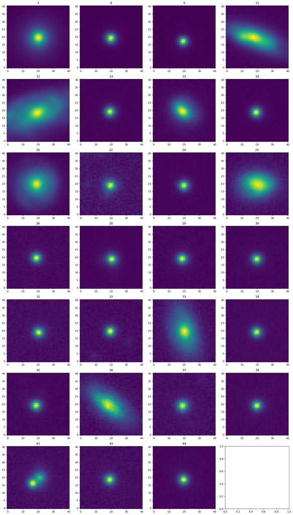

```python
fig, axes = plt.subplots(nrows=nrows, ncols=ncols, figsize=(16, 4 * nrows))
axes = axes.flatten()

idx = 0
for target in targets:

    ra = target['ra']
    dec = target['dec']

    dataset_refs = butler.query_datasets("deep_coadd",
                                         where="band.name='r' AND\
                                         patch.region OVERLAPS POINT(ra, dec)",
                                         bind={"ra": ra, "dec": dec},
                                         with_dimension_records=True,
                                         order_by=["patch.tract"])

    dataId = dataset_refs[0].dataId
    point = SkyCoord(ra, dec, unit='deg')

    wcs = butler.get('deep_coadd.sky_projection', dataId=dataId)
    xy = wcs.sky_to_pixel(point)

    selection_bbox = Box.factory[round(xy.y):round(xy.y)+1,
                                 round(xy.x):round(xy.x)+1].padded(subset_size)
    params = {'bbox': selection_bbox}
    subset = butler.get(dataset_refs[0], parameters=params)

    print(f"Processed ID {target['id']}")

    img_array = subset.image.array
    vmin, vmax = zscale.get_limits(img_array)
    ax = axes[idx]

    ax.imshow(img_array, origin='lower')
    ax.set_title(f"{target['id']}")
    idx = idx+1

plt.tight_layout()
plt.show()
```